# ChengAodi_PS5

### Due date: March 28, Midnight (no late penalties)

### Details

This problem set is accompanied `dprd_ps5.csv`, which contains data on local districts in Indonesia (their social and economic attributes, the results of elections, and the incidence of religious violence ).

**NOTE:** In this problem set, you may use any of the built-in functions in `R`, except where otherwise noted.

**NOTE:** RMarkdown will run the R code in a different R session when it creates your output file of your results. Thus, you will not see the data and objects enter the environment. I strongly recommend you do not create a separate R script file to first produce your answers/results and then insert them into the appropriate sections of the RMarkdown File. It is better to compile your Rmd file as you add answers to ensure it will work correclt.y

**NOTE:** Please save this file using the following format: `LastnameFirstname_ps5.Rmd`. For example: `WeaverMichael_ps4.Rmd` would be the name of my file. This will make the `html` file it produces have the same name.

### Packages

You should install the `magrittr` if you want to use some of the code I have provided on previous problem set solutions. The easiest way to do this is to leave the following code in your homework file:

```r
if (!require(magrittr)) install.packages("magrittr")
require(magrittr)
```

## (1)

Indonesia is an 18,000-island archipelago in Southeast Asia. It is the world’s fourth most populous nation. Free and fair elections have been held on a regular basis since 1999. 87 percent of the country’s population identify as Muslim, while the remainder largely identify as Christian or Hindu. Attacks on religious minorities—notably Christians and heterodox Abangan Muslims—occur regularly. State authorities have sometimes been accused of complicity in such violence.

Indonesia enacted far-reaching political decentralization in the early 2000s. The centerpiece of this policy was the devolution of power to district executives—headed by a regent (the bupati or wali kota)—and to district parliaments. These parliaments, known as the DPRD-II, oversee the district administration, govern the disbursement of central and provincial funds, and craft local laws, including Sharia laws. Members of the DPRD-II are elected to multi-member constituencies comprising three to fifteen seats. Each district has **multiple** DPRD-II constituencies. Legislators serve five-year terms. Ethnographic accounts suggest that legislators tend to be influential community leaders, with significant business, organizational, and religious ties. They are frequently called on to arbitrate disputes and negotiate informal settlements. Members of DPRD-II are elected via proportional representation.

Imagine you are a researcher that wants to know whether the election of more legislators from Islamist parties (parties that explicitly give Islam as their founding ideology) **causes** an increase in religious violence in a community.

You have at your disposal the data contained in `dprd_ps5.csv`. Each row in this data file corresponds to a DPRD-II constituency during the 2004 and 2009 election cycles. These elections took place in April 2004 and 2009, with those elected taking office in October of that year. The data include the following variables:

- `election_cycle`: the year in which the election took place
- `id_dapil`: a unique ID for the multi-seat **constituency**
- `id_kab`: a numeric ID for the administrative **district**
- `kabupaten`: the name of the **district** (if you examine the data, you will see there are multiple constituencies per district in this sample)
- `province`: the name of the province in which the district is located

Constituency-level variables:

- `econ_hh_ag_pct`: fraction of households engaged in agriculture (in the year prior to the election)
- `econ_hh_in_slums_pct`: fraction of households living in “slum” areas (in the year prior to the election)
- `econ_hh_elec_pct`: fraction of households with electricity (in the year prior to the election)
- `econ_kab_support_per_cap`: inter-government transfers from **district** government to the **constituency**, per capita (in the year prior to the election)
- `demo_dcapital_dist`: mean distance to district capital
- `demo_scndschl_per_10k`: secondary schools per 10 thousand people (in the year prior to the election)
- `att_bars_pct`: fraction of villages and municipalities with bars or nightclubs (in the year prior to the election)
- `relg_majority_muslim_pct`: fraction of villages and municipalities that are majority Muslim (in the year prior to the election)
- `relg_mosques_per_10k`: mosques per 10 thousand people (in the year prior to the election)
- `relg_madrasah_per_10k`: madrasah (private, Islamic schools) per 10 thousand people (in the year prior to the election)
- `all_total_votes`: Total votes cast (in the election)
- `all_IT_vs`: Total votes cast for Islamist parties (in the election)
- `all_IT_seats`: Total seats won by Islamist parties (in the election)
- `dapil_seats`: Total seats in the constituency (in the election)
- `enp`: Effective number of parties competing (in the election)
- `pct_security_new_guard`: Fraction of villages hiring a new security guard (3 years after the election)
- `pct_security_new_post`: Fraction of villages building new local security post (3 years after the election)
- `pct_security_new_civil_defense`: Fraction of villages creating a new local security force (3 years after the election)
- `NVM_Violence_1_count`: Number of incidents of religious violence (from when term of office starts until the next election)
- `NVM_Violence_1_deaths`: Number of deaths occurring in religious violence (from when term of office starts until the next election)

`NVM` variables come from a dataset collected by academic researchers that records all kinds of violence reported in newspapers in Indonesia and classifies it in several ways.

`NVM_Violence_1_count` and `NVM_Violence_1_deaths` include violence that is explicitly religious.

- “Inter-religious Violence triggered by disputes between members of different religious groups”
- “Intra-religious Violence triggered by disputes over interpretation within a religion (e.g. between sects)”
- Either perpetrator or victim is religious group: “Affiliated with particular religious groups including religious mass organizations”

#### (a) Load `dprd_ps5.csv`. Create a new variable (call it whatever you like) that is the fraction of votes won by Islamist parties over the number of total votes cast (Referred to as “Islamist vote share” going forward). (2 points)

```r
data <- read.csv("/Users/chengaodi/Desktop/dprd_ps5.csv")
data$islamist_vote_share <- data$all_IT_vs / data$all_total_votes
```

#### (b) Create a new variable (call it whatever you like) that is `1` if *any* seats were won by Islamist parties and `0` otherwise.(Referred to as “Any Islamist Seat” going forward). (2 points)

```r
data$any_islamist_seat <- ifelse(data$all_IT_seats > 0, 1, 0)
```

#### (c) Using the `ggdag` package, https://cran.r-project.org/web/packages/ggdag/vignettes/intro-to-ggdag.html that includes: having Islamist legislators ($D$), deaths in religious violence ($Y$), Islamist vote share, plausible confounding variables that are included in this dataset, and at least two other variables that are not measured in this dataset that you think could **plausibly be confounders**. (4 points)

```r
library(ggdag)
library(dagitty)
```

[figure not shown]

```r
library(ggplot2)
dag <- dagify(
  Y ~ D + islamist_vote_share + relg_majority_muslim_pct + relg_mosques_per_10k +
    econ_hh_ag_pct + demo_scndschl_per_10k + enp + HT + EN,
  D ~ islamist_vote_share + relg_majority_muslim_pct + relg_mosques_per_10k +
    econ_hh_ag_pct + demo_scndschl_per_10k + enp + HT + EN,
  exposure = "D",
  outcome = "Y",
  coords = list(
    D = c(0, 0),
    Y = c(3, 0),
    islamist_vote_share = c(-3, 1),
    relg_majority_muslim_pct = c(-2, 2),
    relg_mosques_per_10k = c(-1, 2),
    econ_hh_ag_pct = c(0, 2),
    demo_scndschl_per_10k = c(1, 2),
    enp= c(2, 2),
    HT = c(-1, -2),
    EN = c(1, -2)
  ),
  latent = c("HT", "EN"),
  labels = c(
    "D" = "Islamist\nLegislators",
    "Y" = "Religious\nViolence",
    "islamist_vote_share" = "Islamist\nVote Share",
    "relg_majority_muslim_pct" = "Muslim\nMajority",
    "relg_mosques_per_10k" = "Mosque\nDensity",
    "econ_hh_ag_pct" = "Agricultural\nHouseholds",
    "demo_scndschl_per_10k" = "Secondary\nSchools",
    "enp" = "Political\nDiversity",
    "HT" = "Historical\nTensions",
    "EN" = "Extremist\nNetworks"
  )
)
ggdag(dag) +
  theme_dag(base_size = 14) +
  geom_dag_point(color = "black", size = 16) +
  geom_dag_text(color = "white", size = 3) +
  geom_dag_edges(edge_color = "black", edge_width = 0.5) +
  geom_dag_label_repel(aes(label = label),
                       color = "black",
                       fill = "white",
                       alpha = 0.8,
                       box.padding = 3,
                       segment.color = "grey50") +
  ggtitle("Islamist Legislators and Religious Violence: Causal Graph") +
  theme(plot.title = element_text(hjust = 0.5, size = 16))
```

#### (d) Referring to your DAG in (c), explain why the **unobserved** variables you identify could be confounders (what is the story you have about how it would generate bias?). For each confounder, explain the expected **direction** of the bias that would be induced by omitting this variable from your regression equation. (6 points)

> **(1)Historical Tensions (HT)** represents long-standing ethnic and religious conflicts in a region. Consider the anti-Chinese violence in Indonesia as an example - both the 1965-1966 massacres and the 1998 riots against Chinese Indonesians reflect deep-seated tensions that have persisted for generations. These historical tensions could simultaneously influence the likelihood of electing Islamist legislators (as voters in regions with religious tensions may be more likely to support candidates emphasizing religious identity) and independently increase the probability of religious violence. If we omit Historical Tensions from our regression, **we would create an upward bias** in the estimated effect of Islamist Legislators on Religious Violence. This positive bias occurs because we would incorrectly attribute violence that actually stems from historical grievances to the presence of Islamist representatives in government.

> **(2)Extremist Networks (EN)** represents the presence and organizational strength of extremist groups operating in an area. These networks could affect both the election of Islamist legislators (by mobilizing voters or intimidating opponents) and directly orchestrate acts of religious violence independent of electoral outcomes. If we fail to account for Extremist Networks in our regression analysis, **we would also create an upward bias** in the estimated relationship between Islamist representation and religious violence. This occurs because violence planned and executed by extremist organizations would be mistakenly attributed to the influence of Islamist legislators. In reality, both the election results and violence might be driven by the same underlying extremist networks, rather than one causing the other.

#### (e) Using regression, estimate the effect of having **any Islamist legislators** on religious violence, conditioning on all **observed** variables that your DAG in (c) show to be possible confounders. Return the results of this analysis as a table, using the `modelsummary` package. (4 points)

```r
library(modelsummary)
data$election_cycle_factor <- as.factor(data$election_cycle)
model_without_year <- lm(NVM_Violence_1_deaths ~ any_islamist_seat + islamist_vote_share +
                           relg_majority_muslim_pct + relg_mosques_per_10k +
                           econ_hh_ag_pct + demo_scndschl_per_10k + enp,
                         data = data)
model_with_year <- lm(NVM_Violence_1_deaths ~ any_islamist_seat + islamist_vote_share +
                        relg_majority_muslim_pct + relg_mosques_per_10k +
                        econ_hh_ag_pct + demo_scndschl_per_10k + enp +
                        election_cycle_factor,
                      data = data)
models_list <- list("Without Year FE" = model_without_year,
                    "With Year FE" = model_with_year)
modelsummary(models_list,
             stars = TRUE,
             title = "Table 1.Effect of Islamist Legislators on Deaths from Religious Violence",
             output = "gt")
```

Table 1.Effect of Islamist Legislators on Deaths from Religious Violence

|  | Without Year FE | With Year FE |
| --- | --- | --- |
| (Intercept) | 0.213*** | 0.213*** |
|  | (0.061) | (0.061) |
| any_islamist_seat | 0.065+ | 0.065+ |
|  | (0.037) | (0.037) |
| islamist_vote_share | 0.144 | 0.189 |
|  | (0.149) | (0.158) |
| relg_majority_muslim_pct | -0.168*** | -0.176*** |
|  | (0.050) | (0.051) |
| relg_mosques_per_10k | 0.001 | 0.001 |
|  | (0.003) | (0.003) |
| econ_hh_ag_pct | -0.151** | -0.146** |
|  | (0.052) | (0.052) |
| demo_scndschl_per_10k | -0.009 | -0.011 |
|  | (0.024) | (0.024) |
| enp | -0.002 | -0.004 |
|  | (0.003) | (0.003) |
| election_cycle_factor2009 |  | 0.025 |
|  |  | (0.028) |
| Num.Obs. | 1991 | 1991 |
| R2 | 0.011 | 0.011 |
| R2 Adj. | 0.007 | 0.007 |
| AIC | 3003.7 | 3004.9 |
| BIC | 3054.1 | 3060.9 |
| Log.Lik. | -1492.852 | -1492.471 |
| F | 3.140 | 2.842 |
| RMSE | 0.51 | 0.51 |

+ p < 0.1, * p < 0.05, ** p < 0.01, *** p < 0.001

#### (f) In light of the coefficient estimate you obtain for **any Islamist legislators** in (e) and the possible unobserved confounders you identified in (d): for each unobserved confounder, would omitting this confounder bias us **in the same direction** as the estimated effect or **in the opposite direction of the estimated effect**? What are the implications of this for what you can infer from the estimated effect of **any Islamist legislators**, if these unobserved variables are truly confounders? (6 points)

> **(1)Historical Tensions (HT)**: This unobserved confounder represents long-standing ethnic and religious conflicts in regions. Areas with deeper historical tensions would likely both elect more Islamist legislators (as voters in these regions may support candidates emphasizing religious identity) and independently experience more religious violence. If omitted from our model, Historical Tensions would bias our estimate in the **same direction as the estimated effect**. This positive bias occurs because we would incorrectly attribute violence stemming from historical grievances to the presence of Islamist representatives.

> **(2)Extremist Networks (EN)**: This confounder represents the presence and strength of extremist organizations in a region. These networks could simultaneously influence the election of Islamist legislators (through voter mobilization or intimidation) and directly orchestrate acts of religious violence. Omitting Extremist Networks would also bias our estimate in the **same direction as the estimated effect**. The positive coefficient we observe might reflect the underlying influence of extremist networks rather than a causal effect of Islamist representation.

> **(3) Implications for inference**: Since both unobserved confounders would bias our estimate in the **same direction** as our observed positive effect, our estimate of 0.065 likely represents an upper bound on the true causal effect. In fact, the actual causal effect of Islamist legislators on religious violence could be substantially smaller or even zero. The observed correlation might primarily reflect the influence of these unobserved confounders rather than a causal relationship. This significantly weakens our ability to make causal claims about Islamist representation increasing religious violence. The positive coefficient should be interpreted with extreme caution, as it may be entirely driven by omitted variable bias from the confounders identified.

#### (g) Using the `sensemakr` package, conduct a sensitivity analysis of the effect of **Islamist Legislators** using **Islamist Voteshare** as a benchmark for the unknown confounders. Generate two plots: (i) the contour plot showing the sensitivity of the effect of **Islamist Legislators** depending on the partial $R^2$ of an unknown confounder with $Y$ and $D$. (ii) the “extreme” sensitivity plot.

For each plot, interpret what these tell us about how “large” unknown confounders would have to be (relative to the benchmark) in order to change our conclusions about the direction of the effect of treatment. (8 points)

```r
library(sensemakr)
```

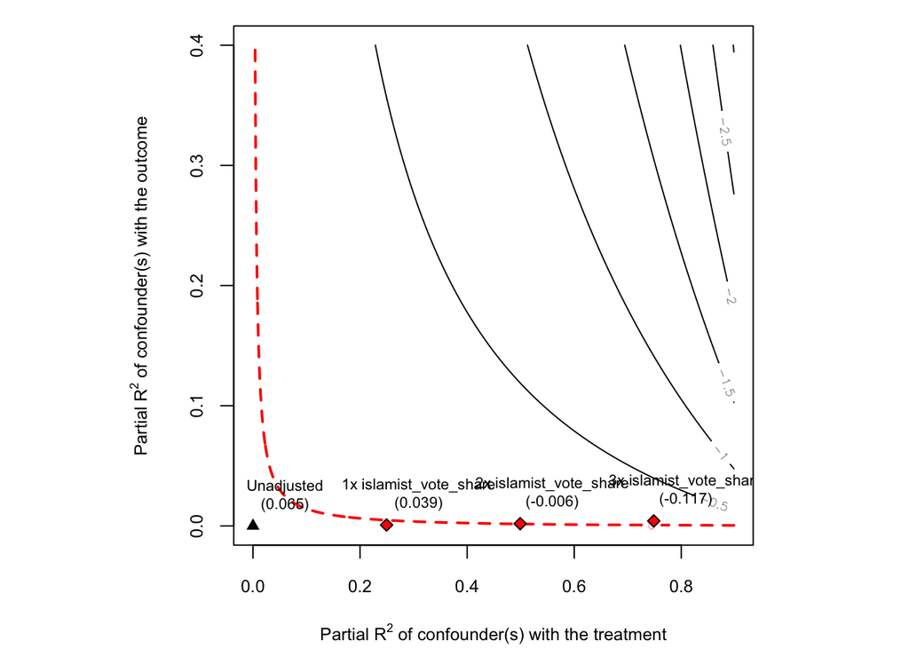

```r
sensitivity <- sensemakr(model = model_without_year,
                         treatment = "any_islamist_seat",
                         benchmark_covariates ="islamist_vote_share",
                         kd = 1:3)
contour_plot <- plot(sensitivity, type = "contour")
```

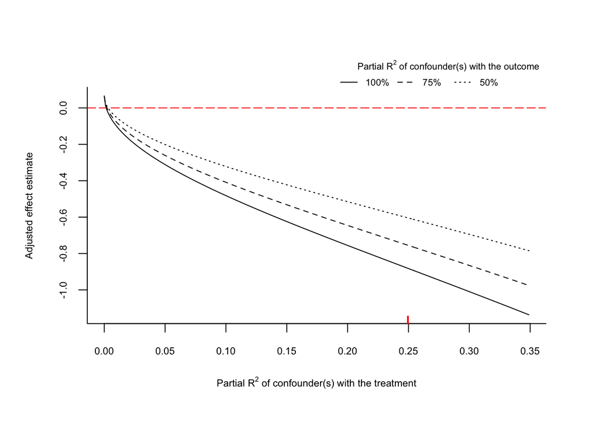

```r
extreme_plot <- plot(sensitivity, type = "extreme")
```

> **(Contour Plot)** From the figure, we see that if some unobserved confounder $U$ explains a relatively large portion of the *residual* variance in the treatment $D$ (i.e., $\mathrm{partial}\,R^2_{U,D}$ is high), even a moderate correlation with the outcome $Y$ (religious‐violence deaths) can be sufficient to eliminate or reverse our estimated positive coefficient $\hat{\beta}_D$. In other words, **any** combination of $\mathrm{partial}\,R^2_{U,D}$ and $\mathrm{partial}\,R^2_{U,Y}$ that lies on or above the red dashed line in the contour plot would be enough to fully offset our estimated effect. Focusing on the benchmark points (e.g., “2×islamist_vote_share”) shows that if an unobserved confounder exerts roughly **twice** the predictive power of the observed covariate “islamist_vote_share” on both $D$ and $Y$, the resulting estimate can become slightly negative (around $-0.006$). This highlights the **fragility** of our result: even a moderately strong confounder (say, $\mathrm{partial}\,R^2_{U,D} \approx 0.2\text{–}0.3$) combined with a modest association to the outcome can readily overturn the apparent positive link between electing Islamist legislators and religious‐violence deaths.

> **(Extreme Plot)** In this extreme plot, the horizontal axis indicates the partial $\mathrm{R}^2_{U,D}$ between a hypothetical confounder $U$ and the treatment $D$ (Islamist legislators), while each curve corresponds to a different partial $\mathrm{R}^2_{U,Y}$ between $U$ and the outcome $Y$ (religious-violence deaths). The vertical axis shows the adjusted effect estimate of $D$ on $Y$ after hypothetically accounting for $U$. The graph shows that even when the confounder explains only about 1–2% of the residual variance in the treatment, the effect estimate begins to decline significantly. At around $\mathrm{partial}\,R^2_{U,D} \approx 0.01$ (1%), the estimated effect approaches zero. More specifically, when the confounder explains about 2.5% ($0.025$) of the residual variance in $D$ and has a 100% association with $Y$ (the solid line), the effect estimate drops to approximately $-0.2$. As $\mathrm{partial}\,R^2_{U,D}$ reaches 5% ($0.05$), the effect further decreases to about $-0.3$ to $-0.4$. A red vertical marker in the graph is positioned near $0.25$ (25%), indicating that even a moderately strong confounder could entirely reverse our relationship. Those results shows that the fragility of our estimate: a confounding variable with moderate association to both Islamist legislators and religious-violence deaths could easily explain away the observed positive correlation between them.

#### (h) Given that we do not know the true DAG, identify all **pre-treatment** variables that you could include as conditioning variables in your regression from (e). Generate a vector of these variable names. (2 points)

```r
pre_treatment_vars <- c("econ_hh_ag_pct", "econ_hh_in_slums_pct", "econ_hh_elec_pct",
  "econ_kab_support_per_cap", "demo_dcapital_dist", "demo_scndschl_per_10k",
  "att_bars_pct", "relg_majority_muslim_pct","relg_mosques_per_10k","relg_madrasah_per_10k",
  "all_total_votes","all_IT_vs","all_IT_seats","islamist_vote_share","enp","dapil_seats","election_cycle_factor")
```

#### (i) Using the `specr` package, or writing your own function (if you so choose): generate a specification curve for the regression you estimated in (e), where you consider all possible combinations of the covariates you listed in (h). (6 points)

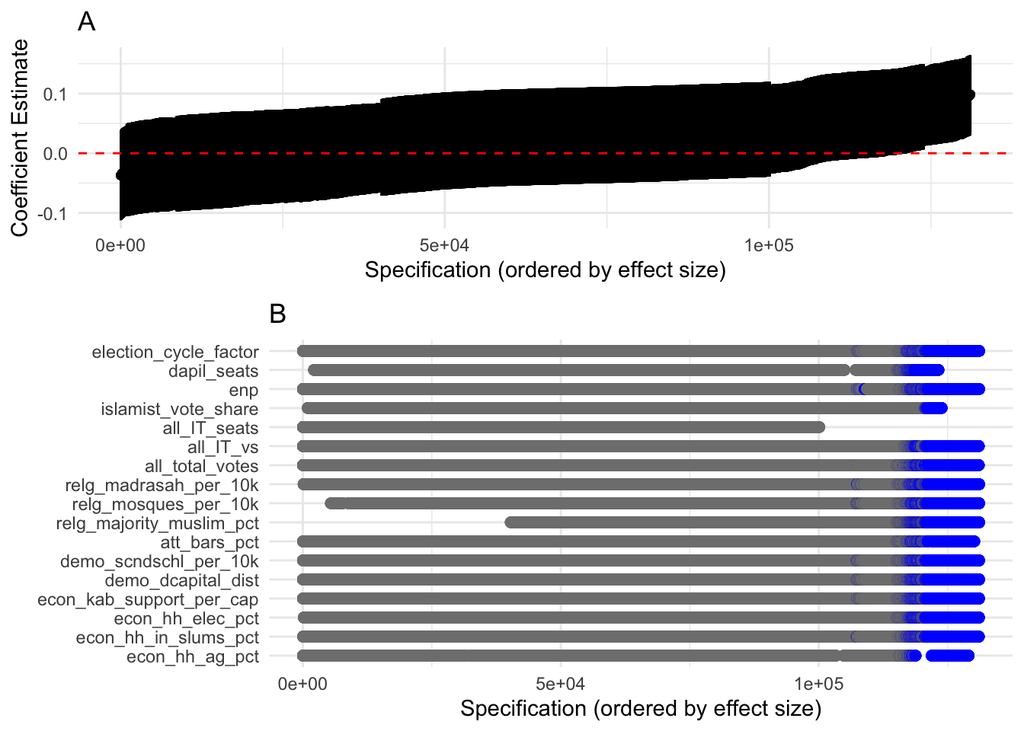

```r
library(ggplot2)
library(gridExtra)
library(reshape2)
run_all_specifications <- function(data, covariates) {
  covs_list <- unlist(lapply(0:length(covariates), function(k) combn(covariates, k, simplify = FALSE)), recursive = FALSE)
  res <- list()
  for (i in seq_along(covs_list)) {
    cset <- covs_list[[i]]
    if (length(cset) > 0) {
      fml <- paste("NVM_Violence_1_deaths ~ any_islamist_seat +", paste(cset, collapse = " + "))
    } else {
      fml <- "NVM_Violence_1_deaths ~ any_islamist_seat"
    }
    mdl <- lm(formula(fml), data = data)
    b <- coef(mdl)["any_islamist_seat"]
    se <- sqrt(vcov(mdl)["any_islamist_seat", "any_islamist_seat"])
    res[[i]] <- data.frame(
      specification = i,
      n_covariates = length(cset),
      covariates = ifelse(length(cset) > 0, paste(cset, collapse = ", "), "None"),
      estimate = b,
      std_error = se,
      lower_ci = b - 1.96*se,
      upper_ci = b + 1.96*se,
      p_value = 2*pt(abs(b/se), df = mdl$df.residual, lower.tail = FALSE)
    )
  }
  do.call(rbind, res)
}
spec_results <- run_all_specifications(data, pre_treatment_vars)
spec_results_ordered <- spec_results[order(spec_results$estimate), ]
spec_results_ordered$specification_ordered <- seq_len(nrow(spec_results_ordered))
p1 <- ggplot(spec_results_ordered, aes(x = specification_ordered, y = estimate)) +
  geom_point() +
  geom_errorbar(aes(ymin = lower_ci, ymax = upper_ci), width = 0) +
  geom_hline(yintercept = 0, linetype = "dashed", color = "red") +
  labs(title = "A", x = "Specification (ordered by effect size)", y = "Coefficient Estimate") +
  theme_minimal()
spec_matrix <- matrix(0, nrow = length(pre_treatment_vars), ncol = nrow(spec_results_ordered))
rownames(spec_matrix) <- pre_treatment_vars
colnames(spec_matrix) <- seq_len(nrow(spec_results_ordered))
for (i in seq_len(nrow(spec_results_ordered))) {
  cset <- unlist(strsplit(spec_results_ordered$covariates[i], ", "))
  if (cset[1] != "None") spec_matrix[cset, i] <- 1
}
long_mat <- melt(spec_matrix)
names(long_mat) <- c("variable", "specification", "included")
long_mat$specification <- as.numeric(long_mat$specification)
sig_data <- data.frame(
  specification = seq_len(nrow(spec_results_ordered)),
  significant = spec_results_ordered$p_value < 0.05,
  positive = spec_results_ordered$estimate > 0)
long_mat <- merge(long_mat, sig_data, by = "specification")
long_mat$color <- "grey50"
long_mat$color[long_mat$included == 1 & long_mat$significant & long_mat$positive] <- "blue"
long_mat$color[long_mat$included == 1 & long_mat$significant & !long_mat$positive] <- "red"
long_mat$color[long_mat$included == 1 & !long_mat$significant] <- "grey50"
p2 <- ggplot(long_mat[long_mat$included == 1, ], aes(x = specification, y = variable)) +
  geom_point(aes(color = color), size = 2) +
  scale_color_identity() +
  labs(title = "B", x = "Specification (ordered by effect size)", y = "") +
  theme_minimal()
combined_plot <- grid.arrange(p1, p2, ncol = 1, heights = c(2, 3))
```

```r
combined_plot
```

#### (j) Using the `sandwich` package, calculate the standard errors for the coefficient on **any Islamist legislators**, using the “HC0”, “HC1”, and “HC3” variance-covariance matrices. Generate a data.frame that contains the coefficient for **any Islamist legislators**, and an additional column for the IID and each robust standard error. (3 points)

```r
library(sandwich)
model <- lm(NVM_Violence_1_deaths ~ any_islamist_seat + islamist_vote_share +
             relg_majority_muslim_pct + relg_mosques_per_10k +
             econ_hh_ag_pct + demo_scndschl_per_10k + enp, data = data)
se_iid <- sqrt(diag(vcov(model)))["any_islamist_seat"]
se_HC0 <- sqrt(diag(vcovHC(model, type = "HC0")))["any_islamist_seat"]
se_HC1 <- sqrt(diag(vcovHC(model, type = "HC1")))["any_islamist_seat"]
se_HC3 <- sqrt(diag(vcovHC(model, type = "HC3")))["any_islamist_seat"]
se_results <- data.frame(
  coefficient = coef(model)["any_islamist_seat"],
  se_iid = se_iid,
  se_HC0 = se_HC0,
  se_HC1 = se_HC1,
  se_HC3 = se_HC3)
se_results
```

```
##                   coefficient     se_iid     se_HC0     se_HC1     se_HC3
## any_islamist_seat  0.06527923 0.03687097 0.02679001 0.02684399 0.02692514
```

#### (k) Create a table using `modelsummary` package that reports the regression results from (e) using the “homoskedastic” errors as well as HC0, HC1, and HC3 robust standard errors. (3 points)

```r
library(modelsummary)
models_list <- list(
  "Homoskedastic" = model,
  "HC0" = model,
  "HC1" = model,
  "HC3" = model)
custom_se <- list(
  sqrt(diag(vcov(model))),
  sqrt(diag(vcovHC(model, type = "HC0"))),
  sqrt(diag(vcovHC(model, type = "HC1"))),
  sqrt(diag(vcovHC(model, type = "HC3"))))
modelsummary(models_list,
             vcov = custom_se,
             stars = TRUE,
             title = "Table.2. Effect of Islamist Legislators on Deaths from Religious Violence with Different Standard Errors",
             output = "gt")
```

Table.2. Effect of Islamist Legislators on Deaths from Religious Violence with Different Standard Errors

|  | Homoskedastic | HC0 | HC1 | HC3 |
| --- | --- | --- | --- | --- |
| (Intercept) | 0.213*** | 0.213*** | 0.213*** | 0.213*** |
|  | (0.061) | (0.078) | (0.078) | (0.079) |
| any_islamist_seat | 0.065+ | 0.065+ | 0.065+ | 0.065+ |
|  | (0.037) | (0.027) | (0.027) | (0.027) |
| islamist_vote_share | 0.144 | 0.144 | 0.144 | 0.144 |
|  | (0.149) | (0.171) | (0.171) | (0.172) |
| relg_majority_muslim_pct | -0.168*** | -0.168*** | -0.168*** | -0.168*** |
|  | (0.050) | (0.080) | (0.080) | (0.080) |
| relg_mosques_per_10k | 0.001 | 0.001 | 0.001 | 0.001 |
|  | (0.003) | (0.002) | (0.002) | (0.002) |
| econ_hh_ag_pct | -0.151** | -0.151** | -0.151** | -0.151** |
|  | (0.052) | (0.070) | (0.071) | (0.071) |
| demo_scndschl_per_10k | -0.009 | -0.009 | -0.009 | -0.009 |
|  | (0.024) | (0.011) | (0.011) | (0.012) |
| enp | -0.002 | -0.002 | -0.002 | -0.002 |
|  | (0.003) | (0.002) | (0.002) | (0.002) |
| Num.Obs. | 1991 | 1991 | 1991 | 1991 |
| R2 | 0.011 | 0.011 | 0.011 | 0.011 |
| R2 Adj. | 0.007 | 0.007 | 0.007 | 0.007 |
| AIC | 3003.7 | 3003.7 | 3003.7 | 3003.7 |
| BIC | 3054.1 | 3054.1 | 3054.1 | 3054.1 |
| Log.Lik. | -1492.852 | -1492.852 | -1492.852 | -1492.852 |
| RMSE | 0.51 | 0.51 | 0.51 | 0.51 |
| Std.Errors | Custom | Custom | Custom | Custom |

+ p < 0.1, * p < 0.05, ** p < 0.01, *** p < 0.001

#### (l) Using the `feols` function in the `fixest` package, estimate the regression from (e) three times, clustering the standard errors by either: `id_dapil`, `id_kab`, or `province`. Report the estimated effect of **any Islamist legislators** for each of these models in a table using the `modelsummary` package. (4 points)

```r
library(fixest)
model_dapil <- feols(NVM_Violence_1_deaths ~ any_islamist_seat + islamist_vote_share +
                     relg_majority_muslim_pct + relg_mosques_per_10k +
                     econ_hh_ag_pct + demo_scndschl_per_10k + enp,
                     data = data,
                     cluster = ~id_dapil)
```

```
## NOTE: 103 observations removed because of NA values (RHS: 103).
```

```r
model_kab <- feols(NVM_Violence_1_deaths ~ any_islamist_seat + islamist_vote_share +
                  relg_majority_muslim_pct + relg_mosques_per_10k +
                  econ_hh_ag_pct + demo_scndschl_per_10k + enp,
                  data = data,
                  cluster = ~id_kab)
```

```
## NOTE: 103 observations removed because of NA values (RHS: 103).
```

```r
model_province <- feols(NVM_Violence_1_deaths ~ any_islamist_seat + islamist_vote_share +
                      relg_majority_muslim_pct + relg_mosques_per_10k +
                      econ_hh_ag_pct + demo_scndschl_per_10k + enp,
                      data = data,
                      cluster = ~province)
```

```
## NOTE: 103 observations removed because of NA values (RHS: 103).
```

```r
modelsummary(list("Cluster by id_dapil" = model_dapil,
                 "Cluster by id_kab" = model_kab,
                 "Cluster by province" = model_province),
             coef_map = c("any_islamist_seat" = "any_islamist_seat"),
             stars = TRUE,
             title = "Table.3.Effect of Islamist Legislators with Different Clustering Levels",
             type="gt")
```

|  | Cluster by id_dapil | Cluster by id_kab | Cluster by province |
| --- | --- | --- | --- |
| any_islamist_seat | 0.065* | 0.065* | 0.065 |
|  | (0.028) | (0.032) | (0.043) |
| Num.Obs. | 1991 | 1991 | 1991 |
| R2 | 0.011 | 0.011 | 0.011 |
| R2 Adj. | 0.007 | 0.007 | 0.007 |
| AIC | 3001.7 | 3001.7 | 3001.7 |
| BIC | 3046.5 | 3046.5 | 3046.5 |
| RMSE | 0.51 | 0.51 | 0.51 |
| Std.Errors | by: id_dapil | by: id_kab | by: province |

+ p < 0.1, * p < 0.05, ** p < 0.01, *** p < 0.001

#### (m) Based on the description of research question and the “assignment” to treatment, discuss which level of clustering (if any) seems most appropriate. Make reference to [Abadei et al (2023)](https://doi.org/10.1093/qje/qjac038). (4 points)

> Abadie et al. (2023) argues that clustering as a design problem, involving two key aspects: sampling design and experimental design. According to this framework, we need to consider: (1) whether the sampling process is clustered; and (2) whether the treatment assignment mechanism is clustered. In this PS, the treatment variable “any_islamist_seat” indicates whether Islamist parties won any seats in a district. From a sampling perspective, the data appears to include all relevant administrative units in Indonesia rather than a random subset. However, from an assignment mechanism perspective, the election of Islamist representatives is clearly clustered geographically, as political attitudes, religious identities, and voting behaviors are correlated within larger geographic units.

> **(1)Electoral district (id_dapil) clustering seems most appropriate** for this PS. First, electoral districts represent the precise level at which the treatment (any_islamist_seat) is assigned through the democratic process - this aligns with Abadie et al.’s (2023) emphasis on clustering at the level of treatment assignment. Second, our dataset appears to include all electoral districts in Indonesia rather than a random sample, which reduces the need for clustering at higher levels. Third, given the cross-sectional time-series nature of our data, electoral district clustering appropriately accounts for potential serial correlation within these political units over time, while maintaining maximum statistical power. Although political attitudes and voting behaviors may show some correlation across larger geographic areas, the electoral system specifically operates at the district level, making this the most relevant unit for capturing the institutional features that directly influence the treatment variable.

> **(2). It should be noted that Kuipers, Nellis and Weaver (2019)** pointed out that after the implementation of decentralization in Indonesia, many DPRD-II constituencies (dapil) experienced large-scale splits, mergers or redraws between 2004 and 2009, resulting in the same geographical area possibly corresponding to multiple old and new dapil IDs. In their paper (not this PS), proposed the “constituency‐cluster” approach to deal with this situation: old and new constituencies with geographical overlap are merged into the same cluster, so that observations of the same area can still be placed in the same cluster when observing across years, avoiding underestimation of residual correlation. However, this PS does not provide a ready-made “cluster ID” and does not describe the method in detail in the title. If we want to strictly follow the original paper’s ideas, we will need more geographical/boundary information to manually construct these clusters. Because in this PS this is not available, we can only cluster each original constituency (id_dapil) or, as a fallback, cluster at the higher level of county (id_kab) level, so as to ensure that constituencies in the same county are not scattered in different clusters.